# progresa_analysis

## Introduction

The [Progresa program](http://en.wikipedia.org/wiki/Oportunidades), a government social assistance program in Mexico. This program, as well as the details of its impact, are described in the paper "[School subsidies for the poor: evaluating the Mexican Progresa poverty program](http://www.sciencedirect.com/science/article/pii/S0304387803001858)", by Paul Shultz (available on Canvas). The data (progresa_sample.csv.gz) is available on canvas in files/data.

The goal is to implement some of the basic econometric techniques that you are learning in class to measure the impact of Progresa on secondary school enrollment rates. The timeline of the program was:

- Baseline survey conducted in 1997
- Intervention begins in 1998, "Wave 1" of data collected in 1998
- "Wave 2 of data" collected in 1999
- Evaluation ends in 2000, at which point the control villages were treated.

The data are actual data collected to evaluate the impact of the Progresa program. In this file, each row corresponds to an observation taken for a given child for a given year. There are two years of data (1997 and 1998), and just under 40,000 children who are surveyed in both years. For each child-year observation, the following variables are collected:

| Variable name | Description |
| --- | --- |
| year | year in which data is collected |
| sex | male = 1 |
| indig | indigenous = 1 |
| dist_sec | nearest distance to a secondary school |
| sc | enrolled in school in year of survey |
| grc | grade enrolled |
| fam_n | family size |
| min_dist | min distance to an urban center |
| dist_cap | min distance to the capital |
| poor | poor = "pobre" |
| progresa | treatment = "basal" |
| hohedu | years of schooling of head of household |
| hohwag | monthly wages of head of household |
| welfare_index | welfare index used to classify poor |
| hohsex | gender of head of household (male=1) |
| hohage | age of head of household |
| age | years old |
| folnum | individual id |
| village | village id |
| sc97 | schooling in 1997 |

```python
import matplotlib.pyplot as plt
import pandas as pd
import numpy as np
import math
import scipy, scipy.stats
from collections import OrderedDict
from scipy.stats import ttest_ind
import statsmodels.api as sm
import statsmodels.formula.api as smf
```

## Part 1: Descriptive analysis

### 1.1 Summary Statistics

Report summary statistics (mean, standard deviation, and number of missings) for all of the demographic variables in the dataset (i.e., everything except year, folnum, village). Present the actual levels for 'progresa' and 'poor'. Do these fit with the documentation above?

Present these in a single table alphabetized by variable name. Do NOT simply expect the grader to scroll through your output!

```python
df = pd.read_csv('progresa_sample.csv.gz')
df = pd.DataFrame(df)
```

```python
df = pd.read_csv('progresa_sample.csv.gz')
df = pd.DataFrame(df)
df.drop('year', axis=1, inplace=True)
df.drop('folnum', axis=1, inplace=True)
df.drop('village', axis=1, inplace=True)
# For progresa: basal = treatment which we will replace with 1, and w/o treatment will stay as 0
# For poor: probre = 0, and no probre = 1
df['poor'] = df['poor'].replace(['pobre'], 0)
df['poor'] = df['poor'].replace(['no pobre'], 1)
df['progresa'] = df['progresa'].replace(['basal'], 1)
df['progresa'] = df['progresa'].replace(['0'], 0)
var_name = np.sort(np.asarray(df.columns))

mean = pd.DataFrame.mean(df)
stdev = pd.DataFrame.std(df)
missing = df.isnull().sum(axis=0)
```

```python
data = pd.DataFrame(OrderedDict({"var_name": df.columns, "mean": mean.values, "stdev": stdev.values, "missing": missing.values}))
data = data.sort_values("var_name")
data
```

|  | var_name | mean | stdev | missing |
| --- | --- | --- | --- | --- |
| 15 | age | 11.366460 | 3.167744 | 0 |
| 7 | dist_cap | 147.674452 | 76.063134 | 0 |
| 2 | dist_sec | 2.418910 | 2.234109 | 0 |
| 5 | fam_n | 7.215715 | 2.352900 | 0 |
| 4 | grc | 3.963537 | 2.499063 | 6549 |
| 16 | grc97 | 3.705372 | 2.572387 | 0 |
| 14 | hohage | 44.436717 | 11.620372 | 10 |
| 10 | hohedu | 2.768104 | 2.656106 | 0 |
| 13 | hohsex | 0.925185 | 0.263095 | 20 |
| 11 | hohwag | 586.985312 | 788.133664 | 0 |
| 1 | indig | 0.298324 | 0.457525 | 300 |
| 6 | min_dist | 103.447520 | 42.089441 | 0 |
| 8 | poor | 0.153502 | 0.360473 | 0 |
| 9 | progresa | 0.615663 | 0.486441 | 0 |
| 3 | sc | 0.819818 | 0.384342 | 8453 |
| 17 | sc97 | 0.813922 | 0.389172 | 3872 |
| 0 | sex | 0.512211 | 0.499854 | 24 |
| 12 | welfare_index | 690.346564 | 139.491130 | 210 |

### 1.2 Differences at baseline?

Are the baseline (1997) demographic characteristics **for the poor** different in treatment and control villages? Hint: Use a T-Test to determine whether there is a statistically significant difference in the average values of each of the variables in the dataset. Focus only on the data from 1997 for individuals who are poor (i.e., poor=='pobre').

Present your results in a single table with the following columns and 14 (or so) rows:

| Variable name | Average value (Treatment villages) | Average value (Control villages) | Difference (Treat - Control) | p-value |
| --- | --- | --- | --- | --- |
| Male | ? | ? | ? | ? |

```python
# your code here
df_poor = pd.read_csv('progresa_sample.csv.gz')
df_poor = pd.DataFrame(df_poor)

# Clean Variables
df_poor['poor'] = df_poor['poor'].replace(['pobre'], 0)
df_poor['poor'] = df_poor['poor'].replace(['no pobre'], 1)
df_poor['progresa'] = df_poor['progresa'].replace(['basal'], 1)
df_poor['progresa'] = df_poor['progresa'].replace(['0'], 0)
df_poor = df_poor.query('poor < 1')
df_poor = df_poor.query('year == 97')

# # Check if we have data only on the poor
# check = df_poor['poor'].unique()
df_poor = pd.DataFrame.dropna(df_poor)
# Converting the t
t = df_poor.query('progresa > 0')
no_t = df_poor.query('progresa < 1')
t_mean = pd.DataFrame.mean(t)
no_t_mean = pd.DataFrame.mean(no_t)
difference = t_mean - no_t_mean
p_value = ttest_ind(no_t, t)

data_poor = pd.DataFrame(OrderedDict({"Variable_Name": df_poor.columns,"Avg_Val_Control": no_t_mean.values,  "Avg_Val_Treatment": t_mean.values,
                                     "Difference": difference.values, "p_value": p_value[1]}))
# Remove poor and progresa
data_poor = data_poor.drop([0, 9, 10, 17, 18])
data_poor
```

[output not shown]

```python
significant = data_poor.query('p_value < .05')
significant
```

[output not shown]

### 1.3 Interpretation

- A: Are there statistically significant differences between treatment and control villages as baseline?
- B: Why does it matter if there are differences at baseline?
- C: What does this imply about how to measure the impact of the treatment?

#### Interpretation

- A: There are few significant differences between treatment and control villages as baseline, however these do not include the entrollment rate. These include head of household in eduation/wages, and minimum distance to an urban center and to the capital.
- B: These factors matter because these could impact a part of a change in enrollment that are NOT caused by the Progresa program, which we are testing for. We are assumming that these groups are picked randomly so there should be no other differences within our repreasentative groups in this experiment. It should be so that both groups are equally similar.
- C: Since there are some variables that are significantly different in both the control and experimental groups, we must take into account these factors when observing if the Progresa program had a positive/negative affect on the enrollment rates.

### 1.4 Graphical exploration, part 1

For each level of household head education, compute the average enrollment rate in 1997. Create a scatterplot that shows this relationship. What do you notice?

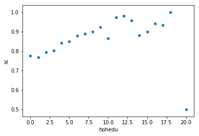

```python
df_97 = pd.read_csv('progresa_sample.csv.gz')
df_97 = pd.DataFrame(df_97.query('year==97').groupby('hohedu', as_index=False)['sc'].mean())
graph = df_97.plot(x='hohedu', y='sc', kind='scatter')
plt.show()
```

#### Interpretation

The scatter plot shows that there is generally a positive correlation between head of household education and the average enrollment rate within the year 1997 with the exception of some dips.

### 1.5 Graphical exploration, part 2

1. On each histogram, draw a vertical line that intersects the x-axis at the average value (across all households). Does there appear to be a difference? Is this difference statistically significant?

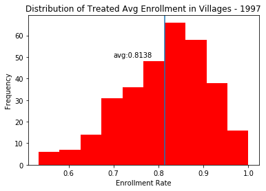

```python
treated_97 = pd.read_csv('progresa_sample.csv.gz')
treated_97 = pd.DataFrame(treated_97.query('year==97').query('progresa=="basal"').query('poor=="pobre"'))
treated_97 = pd.DataFrame(treated_97.groupby(['village'], as_index=False)['sc'].mean())
avg_97 = treated_97['sc'].mean()
plt.hist(treated_97['sc'], facecolor='r')
plt.title('Distribution of Treated Avg Enrollment in Villages - 1997')
plt.text(.7, 50, 'avg:'+str(round(avg_97, 4)))
plt.ylabel('Frequency')
plt.xlabel('Enrollment Rate')
plt.axvline(x= avg_97)
plt.show()
```

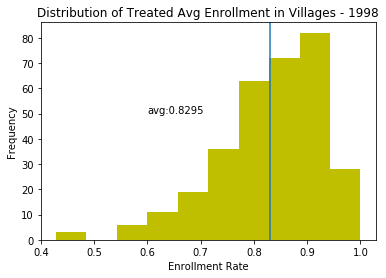

```python
treated_98 = pd.read_csv('progresa_sample.csv.gz')
treated_98 = pd.DataFrame(treated_98.query('year==98').query('progresa=="basal"').query('poor=="pobre"'))
treated_98 = pd.DataFrame(treated_98.groupby(['village'], as_index=False)['sc'].mean())
avg_98 = treated_98['sc'].mean()

plt.hist(treated_98['sc'], facecolor='y')
plt.text(.6, 50, 'avg:'+str(round(avg_98, 4)))
plt.title('Distribution of Treated Avg Enrollment in Villages - 1998')
plt.ylabel('Frequency')
plt.xlabel('Enrollment Rate')
plt.axvline(x= avg_98)
plt.show()
```

```python
p_value = ttest_ind(treated_97['sc'], treated_98['sc'])
p_value
```

```
Ttest_indResult(statistic=-2.0157134865156379, pvalue=0.04424870036572115)
```

Looking at both histograms, the year 1997 seems to be more normally distributed while the year 1998 is a bit more left skewed, with higher enrollment rates > .7. The p-value that is < .05 suggests that we can reject the null hypothesis and that two means are statistically significant in difference.

## Part 2: Measuring Impact

Our goal is to estimate the causal impact of the PROGRESA program on the social and economic outcomes of individuals in Mexico. We will focus on the impact of the program on the poor (those with poor=='pobre'), since only the poor were eligible to receive the PROGRESA assistance.

### 2.1 Simple differences: T-test

Begin by estimating the impact of Progresa using "simple differences." Restricting yourself to data from 1998 (after treatment), calculate the average enrollment rate among **poor** households in the Treatment villages and the average enrollment rate among **poor** households in the control villages. Use a t-test to determine if this difference is statistically significant. What do you conclude?

```python
df_98 = pd.read_csv('progresa_sample.csv.gz')
df_98 = pd.DataFrame(df_98.query('year==98').query('poor=="pobre"')).dropna()
control_98 = df_98.query('progresa=="0"')
treatment_98 = df_98.query('progresa=="basal"')
# Averages
print("Control Averages - 1998:", control_98['sc'].mean())
print("Treatment Avgerages - 1998:", treatment_98['sc'].mean())
print("Difference in Averages:",  treatment_98['sc'].mean() - control_98['sc'].mean())
# T-test
print(ttest_ind(control_98['sc'], treatment_98['sc']))
```

```
Control Averages - 1998: 0.810923092511906
Treatment Avgerages - 1998: 0.849257030578411
Difference in Averages: 0.03833393806650498
Ttest_indResult(statistic=-8.1016503053003746, pvalue=5.656455605358843e-16)
```

In the year 1998, the difference in means of the control and treatment groups is .038, giving a statistically significant p-value of 5.6e-16. This means that we can conclude the enrollment rate means are statistically significant in different, and we can reject the null hypothesis.

### 2.2 Simple differences: Regression

Estimate the effects of Progresa on enrollment using a regression model, by regressing the 1998 enrollment rates **of the poor** on treatment assignment. Do not include any additional control variables. Discuss the following:

- Based on this model, how much did Progresa increase the likelihood of a child enrolling?
- How does your regression estimate compare to your t-test estimate from part 2.1?
- Based on this regression model, can we reject the null hypothesis that the treatment effects are zero?
- What is the counterfactual assumption underlying this regression?

Note: I recommend to use statsmodels.formula.api as this allows to use convenient R-style formulas and provedes nice summaries of the results.

```python
model = smf.ols(formula='sc ~ progresa', data=df_98)
result = model.fit()
result.summary()
```

OLS Regression Results

| Dep. Variable: | sc | R-squared: | 0.003 |
| --- | --- | --- | --- |
| Model: | OLS | Adj. R-squared: | 0.002 |
| Method: | Least Squares | F-statistic: | 65.64 |
| Date: | Mon, 12 Feb 2018 | Prob (F-statistic): | 5.66e-16 |
| Time: | 10:18:18 | Log-Likelihood: | -11171. |
| No. Observations: | 26155 | AIC: | 2.235e+04 |
| Df Residuals: | 26153 | BIC: | 2.236e+04 |
| Df Model: | 1 |  |  |
| Covariance Type: | nonrobust |  |  |

|  | coef | std err | t | P>\|t\| | [0.025 | 0.975] |
| --- | --- | --- | --- | --- | --- | --- |
| Intercept | 0.8109 | 0.004 | 217.190 | 0.000 | 0.804 | 0.818 |
| progresa[T.basal] | 0.0383 | 0.005 | 8.102 | 0.000 | 0.029 | 0.048 |

| Omnibus: | 7487.800 | Durbin-Watson: | 1.734 |
| --- | --- | --- | --- |
| Prob(Omnibus): | 0.000 | Jarque-Bera (JB): | 15756.374 |
| Skew: | -1.796 | Prob(JB): | 0.00 |
| Kurtosis: | 4.245 | Cond. No. | 3.02 |

From the OLS regression results, we can see that progresa will increase the likelihood of a child enrolling by .0383. However, our low R-squared value indicates that there may be other control variables that affect the outcome of the enrollment rate.

Comparing the previous t-test estimate and our findings, the two results do align as the p-values for both are fairly small. The difference between the two groups are also the same as the coefficent found in our data table.

This does further supports our notion of rejecting the null hypothesis and that the two means are statistically different. However, we should do more work and include other data variables within our regression to show goodness of fit.

### 2.3 Multiple Regression

Re-run the above regression estimated but this time include a set of relevant control variables. Include, for instance, age, distance to a secondary school, gender, education of household head, welfare index, indigenous, etc.

- How do the controls affect the point estimate of treatment effect?
- How do the controls affect the standard error on the treatment effect?
- How do you interpret the differences (or similarities) between your estimates of 2.2 and 2.3?

```python
model = smf.ols(formula='sc ~ progresa+age+min_dist+dist_sec+hohedu+indig+sex', data=df_98)
result = model.fit()
result.summary()
```

OLS Regression Results

| Dep. Variable: | sc | R-squared: | 0.268 |
| --- | --- | --- | --- |
| Model: | OLS | Adj. R-squared: | 0.267 |
| Method: | Least Squares | F-statistic: | 1365. |
| Date: | Sun, 11 Feb 2018 | Prob (F-statistic): | 0.00 |
| Time: | 23:55:24 | Log-Likelihood: | -7129.9 |
| No. Observations: | 26155 | AIC: | 1.428e+04 |
| Df Residuals: | 26147 | BIC: | 1.434e+04 |
| Df Model: | 7 |  |  |
| Covariance Type: | nonrobust |  |  |

|  | coef | std err | t | P>\|t\| | [0.025 | 0.975] |
| --- | --- | --- | --- | --- | --- | --- |
| Intercept | 1.4630 | 0.011 | 137.045 | 0.000 | 1.442 | 1.484 |
| progresa[T.basal] | 0.0319 | 0.004 | 7.862 | 0.000 | 0.024 | 0.040 |
| age | -0.0651 | 0.001 | -92.993 | 0.000 | -0.066 | -0.064 |
| min_dist | 0.0006 | 4.97e-05 | 12.544 | 0.000 | 0.001 | 0.001 |
| dist_sec | -0.0103 | 0.001 | -11.098 | 0.000 | -0.012 | -0.008 |
| hohedu | 0.0079 | 0.001 | 9.979 | 0.000 | 0.006 | 0.009 |
| indig | 0.0312 | 0.004 | 6.995 | 0.000 | 0.022 | 0.040 |
| sex | 0.0303 | 0.004 | 7.704 | 0.000 | 0.023 | 0.038 |

| Omnibus: | 2972.808 | Durbin-Watson: | 1.727 |
| --- | --- | --- | --- |
| Prob(Omnibus): | 0.000 | Jarque-Bera (JB): | 4095.121 |
| Skew: | -0.959 | Prob(JB): | 0.00 |
| Kurtosis: | 3.281 | Cond. No. | 627. |

With multi-variable regression, the progresa coefficent or the likelihood of enrolling falls from .0383 to .0319. The standard error also falls from .005 to .004.

Before with no control variables, the coefficent is .0383 but is reduced when other variables are taken to account. This gives a better representation of what the actaul coeffecient would be including all other possible factors. Including these factors also increased the R-squared value, which further supplement how including other factors allows for a better model of the progresa program effect on enrollment.

### 2.4 Difference-in-Difference, version 1 (tabular)

Thus far, we have computed the effects of Progresa by estimating the difference in 1998 enrollment rates across villages. An alternative approach would be to compute the treatment effect using a difference-in-differences framework.

Begin by estimating the average treatment effects of the program for poor households using data from 1997 and 1998. Specifically, calculate:

a) the difference (between 1997 and 1998) in enrollment rates among poor households in treated villages

b) the difference (between 1997 and 1998) in enrollment rates among poor households in control villages.

c) The difference between these two differences is your estimate.

- What is your estimate of the impact, and how does it compare to your earlier (simple difference) results?
- What is the counterfactual assumption underlying this estimate?

```python
data = pd.read_csv('progresa_sample.csv.gz')
data = pd.DataFrame(data.query('poor=="pobre"')).dropna()

control_98 = data.query('progresa=="0"').query('year==98')
treatment_98 = data.query('progresa=="basal"').query('year==98')

control_97 = data.query('progresa=="0"').query('year==97')
treatment_97 = data.query('progresa=="basal"').query('year==97')

treated_diff = treatment_98['sc'].mean() - treated_97['sc'].mean()
control_diff = control_98['sc'].mean() - control_97['sc'].mean()

print("Treated Differences:", treated_diff)
print("Controlled Differences:", control_diff)
print("Difference in Differences:", treated_diff + control_diff)
```

```
Treated Differences: 0.03541761951876088
Controlled Differences: -0.004142465805002105
Difference in Differences: 0.031275153713758774
```

The counterfactual assumption underlying this estimate is that considering all other control variables as constant, the progresa program caused the increase in likelihood of enrollment rate, or that in the absense of the progresa program, the enrollment rate should be the same within the years.

The controlled differences are very close to 0, which is what we want as we are choosing a random representative sample that should be the same when there is no Progresa program that is applied and all other variables are the same. The treated differences can be observed from the fact that in 1998, the program was conducted while in 1997, only the baseline curvey was conducted.

### 2.5 Difference-in-Difference, version 2 (regression)

Now use a regression specification to estimate the average treatment effects of the program in a difference-in-differences framework. Include at least 5 control variables.

- What is your estimate of the impact of Progresa? Be very specific in interpreting your coefficients and standard errors, and make sure to specify exactly what units you are measuring and estimating.
- How do these estimates of the treatment effect compare to the estimates based on the simple difference?
- How do these estimates compare to the difference-in-difference estimates from 2.4 above? What accounts for these differences?
- What is the counterfactual assumption underlying this regression?

```python
data = pd.read_csv('progresa_sample.csv.gz')
data = pd.DataFrame(data.query('poor=="pobre"')).dropna()

data['progresa'] = data['progresa'].astype('category')
data['poor'] = data['poor'].astype('category')
data['year'] = data['year'].astype('category')

model = smf.ols(formula='sc ~ progresa+(progresa*year)+year+age+min_dist+dist_sec+hohedu+hohage+indig+sex', data=data)
result = model.fit()
result.summary()
```

OLS Regression Results

| Dep. Variable: | sc | R-squared: | 0.281 |
| --- | --- | --- | --- |
| Model: | OLS | Adj. R-squared: | 0.281 |
| Method: | Least Squares | F-statistic: | 2223. |
| Date: | Mon, 12 Feb 2018 | Prob (F-statistic): | 0.00 |
| Time: | 09:25:45 | Log-Likelihood: | -16073. |
| No. Observations: | 56893 | AIC: | 3.217e+04 |
| Df Residuals: | 56882 | BIC: | 3.227e+04 |
| Df Model: | 10 |  |  |
| Covariance Type: | nonrobust |  |  |

|  | coef | std err | t | P>\|t\| | [0.025 | 0.975] |
| --- | --- | --- | --- | --- | --- | --- |
| Intercept | 1.4218 | 0.009 | 156.734 | 0.000 | 1.404 | 1.440 |
| progresa[T.basal] | 0.0019 | 0.004 | 0.515 | 0.606 | -0.005 | 0.009 |
| year[T.98] | 0.0326 | 0.004 | 7.401 | 0.000 | 0.024 | 0.041 |
| progresa[T.basal]:year[T.98] | 0.0304 | 0.006 | 5.454 | 0.000 | 0.019 | 0.041 |
| age | -0.0655 | 0.000 | -141.514 | 0.000 | -0.066 | -0.065 |
| min_dist | 0.0006 | 3.42e-05 | 16.969 | 0.000 | 0.001 | 0.001 |
| dist_sec | -0.0097 | 0.001 | -15.262 | 0.000 | -0.011 | -0.008 |
| hohedu | 0.0076 | 0.001 | 13.001 | 0.000 | 0.006 | 0.009 |
| hohage | 0.0003 | 0.000 | 2.588 | 0.010 | 8.22e-05 | 0.001 |
| indig | 0.0342 | 0.003 | 11.189 | 0.000 | 0.028 | 0.040 |
| sex | 0.0332 | 0.003 | 12.341 | 0.000 | 0.028 | 0.039 |

| Omnibus: | 5479.202 | Durbin-Watson: | 1.489 |
| --- | --- | --- | --- |
| Prob(Omnibus): | 0.000 | Jarque-Bera (JB): | 7234.508 |
| Skew: | -0.871 | Prob(JB): | 0.00 |
| Kurtosis: | 3.128 | Cond. No. | 850. |

- What is your estimate of the impact of Progresa? Be very specific in interpreting your coefficients and standard errors, and make sure to specify exactly what units you are measuring and estimating.

The two coefficents we are focusing on are progresa[T.basal], and progresa[T.basal]:year[T.98]. Progresa now is .0019, with a standard error of .004, and a p value of .606. Since this is > .05, we will consider this not significant enough to be considered in our estimations.  
progresa[T.basal]:year[T.98] is .0304 with a standard error of .006, and a p-value < .05, which indicates that those in the year 1998 with threatment has an increase in enrollment likelihood by .0304. While small (.006) we do see an increase in standard error, telling us that there is a bit more spread than in our findings in 2.3.

- How do these estimates of the treatment effect compare to the estimates based on the simple difference?

- How do these estimates compare to the difference-in-difference estimates from 2.4 above? What accounts for these differences?

- What is the counterfactual assumption underlying this regression?

The counterfactual assumption: Keeping control variables as a constant, if the progresa program was not present in the treatement and base line years of 1997 to 1998 then there should be no difference between enrollment rates of (.0304) between the years.

### 2.6 Summary

- Based on all the analysis you have undertaken to date, do you believe that Progresa had a causal impact on the enrollment rates of poor households in Mexico? Explain by referring to the methods and results above.

We looked at numerous ways to calculate the effects of Progresa on the enrollment rates that gradually increased in specifications that led to the same conclusion that the Progresa program does indeed have a positive effect on enrollment rates.

In our baseline 1.2 observation we saw that our p-values in the enrollment rates were not significant by just comparing the poor treatment in 1997, because this year was a time period that only a baseline survey was conducted. As we continue to 1.5 where we observed both years in treatment for 1997 and 1998 for poor villages, we obtained a p-value for the means of enrollment of .04, which showed a statistically significant difference.

In 2.3, 2.4 and 2.5, with calculated a simple linear regression, multi-variable regression, and then DiD with treated and controlled villages. Each step better specified our estimate, and took into account the spread throughout the years, and other control variables that still led to a difference in enrollment rate that was statistically significant.

While the coefficents varied from caluclation to calculation, we continuously obtained the same result with low p-values < .05 that indicated statistical significance in coefficents with progresa over time. Bottom Line: Progresa has a causual impact on enrollment rates of treated villages over time.